# Mettre en oeuvre la sécurité dans une Architecture Micro-Services avec Spring

## Les bases de la sécurité

### L'encryptage du mot de passe

Spring Security fournit un support complet pour l'authentification, l'autorisation et la protection contre les intrusions courantes. Il fournit également l'intégration d'autres bibliothèques pour simplifier son utilisation.

Une manière courante d'authentifier les utilisateurs consiste à demander à l'utilisateur de saisir un nom d'utilisateur et un mot de passe. Une fois l'authentification effectuée, nous connaissons l'identité et pouvons effectuer une autorisation.

L'interface `PasswordEncoder` de Spring Security est utilisée pour effectuer une transformation unidirectionnelle d'un mot de passe afin de permettre le stockage sécurisé de ce mot de passe. Étant donné que `PasswordEncoder` est une transformation unidirectionnelle, elle n'est pas prévue lorsque la transformation du mot de passe doit être bidirectionnelle (c'est-à-dire stocker les informations d'identification utilisées pour s'authentifier auprès d'une base de données). En général, l'interface `PasswordEncoder` est utilisée pour stocker un mot de passe qui doit être comparé à un mot de passe fourni par l'utilisateur au moment de l'authentification.

L'implémentation `BCryptPasswordEncoder` utilise l'algorithme "bcrypt" largement pris en charge pour "hasher" les mots de passe. Afin de le rendre plus résistant au craquage de mot de passe, "bcrypt" est délibérément lent. Comme les autres fonctions adaptatives unidirectionnelles, il doit être réglé pour prendre environ 1 seconde afin de vérifier un mot de passe sur votre système. L'implémentation par défaut de `BCryptPasswordEncoder` utilise un paramètre de force 10 comme mentionné dans le Javadoc de `BCryptPasswordEncoder`. Il est préférable de régler et de tester le paramètre de force sur votre propre système afin que la vérification d'un mot de passe prenne environ 1 seconde.

### "Cross Site Request Forgery" (CSRF) ou Falsification de demande intersite

L’objet de cette attaque est de transmettre, à un utilisateur authentifié, une requête HTTP falsifiée qui pointe sur une action interne au site, afin qu'il l'exécute sans en avoir conscience et en utilisant ses propres droits.

Afin de pévenir ce genre d'attaque, on utilise des jetons de validité (ou "Token") dans les formulaires. La création d'un "token" est basée sur le chiffrement d'un identifiant utilisateur, un nom et un horodatage. Le serveur doit vérifier la correspondance du jeton envoyé en recalculant cette valeur et en la comparant avec celle reçue.

On ajoute souvent la vérification du site référent dans les pages sensibles, ce qui consiste à bloquer la requête du client si la valeur du site référent est différente de la page d'où il doit théoriquement provenir.

## Créer et importer le projet Maven avec Spring Boot

- Dépendances :
  - Spring Web
  - Spring Security
  - Spring Data MongoDB
  - Thymeleaf
  - Lombok
  - Validation
- Paramètres :
  - Java 11
  - Jar

## Créer les entités `GestionnairePrevoyance` et `Role`

Le moyen de persistance est MongoDb déjà étudié précédemment. Reprendre le même serveur, la même base, les mêmes accès.

### La classe `GestionnairePrevoyance`

- Utiliser Lombok
- Utiliser une collection pour MongoDB (par ex. : `gestionprevdb`)
- Attributs
  - `String id` à mettre en identifiant JPA
  - `String mail` à indexer et ne pas accepter les doublons
  - `String motdepasse`
  - `String nomcomplet`
  - `boolean active`
- créer une relation 1 à plusieurs avec l'entité `Role`, ce qui se traduit en MongoDB par :

  ```
  @DBRef
    private Set<Role> roles;
  ```

### La classe `Role`

- Utiliser Lombok
- Utiliser une collection pour MongoDB (par ex. : `role`)
- Attributs
  - `String id` à mettre en identifiant JPA
  - `String role` à indexer et ne pas accepter les doublons

## Créer les DAO

- Pour `GestionnairePrevoyance`, indiquer seulement la recherche par mail
- Pour `Role`, indiquer seulement la recherche par rôle

## Créer la couche service `GestionnairePrevoyanceService`

- Créer une classe `GestionnairePrevoyanceService` qui implémente `org.springframework.security.core.userdetails.UserDetailsService`

L'interface `UserDetailsService` est utilisée par `DaoAuthenticationProvider` pour récupérer un nom d'utilisateur, un mot de passe et d'autres attributs afin de s'authentifier avec un nom d'utilisateur et un mot de passe. Spring Security fournit des implémentations en mémoire de JDBC et de `UserDetailsService`. Vous pouvez définir une authentification personnalisée en exposant un `UserDetailsService` personnalisé en tant que "bean".

- Ajouter l'annotation `@Service` pour que Spring instancie un singleton de cette classe et le place dans son conteneur (contexte). La différence avec `@Component` est que Spring rend toutes les méthodes transactionnelles.
- Injecter la couche DAO
- Injecter un objet ("bean") de type `org.springframework.security.crypto.bcrypt.BCryptPasswordEncoder` pour encrypter le mot de passe
- Créer une méthode pour rechercher le `GestionnairePrevoyance` par son mail
- Créer une méthode pour enregistrer un nouveau `GestionnairePrevoyance`, crypter le mot de passe et définir un rôle. Pour l'instant, nous utiliserons le rôle `ADMIN` pour tous les nouveaux `GestionnairePrevoyance` enregistrés :

```
public void sauveGestionnairePrevoyance(GestionnairePrevoyance gestionnairePrevoyance) {
        gestionnairePrevoyance.setMotdepasse(bCryptPasswordEncoder.encode(gestionnairePrevoyance.getMotdepasse()));
        gestionnairePrevoyance.setActive(true);
        Role gestionnairePrevoyanceRole = roleRepository.findByRole("ADMIN");
        gestionnairePrevoyance.setRoles(new HashSet<>(Arrays.asList(gestionnairePrevoyanceRole)));
        gestionnairePrevoyanceRepository.save(gestionnairePrevoyance);
    }
```

- Redéfinir la méthode `loadUserByUsername` de l'interface `UserDetailsService` qui vérifie le mail avec celui de la collection MongoDB. Cette méthode appelle une méthode que vous devez créer pour convertir les rôles en tant que collection `GrantedAuthority`

```
@Override
    public UserDetails loadUserByUsername(String mail) throws UsernameNotFoundException {

        GestionnairePrevoyance gestionnairePrevoyance = gestionnairePrevoyanceRepository.findByMail(mail);
        if(gestionnairePrevoyance != null) {
            List<GrantedAuthority> autorisations = getGestionnairePrevoyanceAutorisation(gestionnairePrevoyance.getRoles());
            return autoriserGestionnairePrevoyance(gestionnairePrevoyance, autorisations);
        } else {
            throw new UsernameNotFoundException("Non autorisé.");
        }
    }
```

```
private List<GrantedAuthority> getGestionnairePrevoyanceAutorisation(Set<Role> gestionnairePrevoyanceRoles) {
        Set<GrantedAuthority> roles = new HashSet<>();
        gestionnairePrevoyanceRoles.forEach((role) -> {
            roles.add(new SimpleGrantedAuthority(role.getRole()));
        });

        List<GrantedAuthority> grantedAuthorities = new ArrayList<>(roles);
        return grantedAuthorities;
    }
```

- Ajouter la méthode pour connecter le `GestionnairePrevoyance` MongoDB au `GestionnairePrevoyance` Spring Security comme appelé depuis la méthode `loadUserByUsername`

```
private UserDetails autoriserGestionnairePrevoyance(GestionnairePrevoyance gestionnairePrevoyance, List<GrantedAuthority> autorisations) {
        return new org.springframework.security.core.userdetails.User(gestionnairePrevoyance.getMail(), gestionnairePrevoyance.getMotdepasse(), autorisations);
    }
```

## Créer le Contrôleur

- À des fins de simplifications pédagogiques, créer un contrôleur unique `ConnexionControleur` annoté `@Controller`
- Injecter la couche service
- Créer une vue et un modèle de la page d'accueil en utilisant la classe `org.springframework.web.servlet.ModelAndView`

```
@RequestMapping(value = {"/","/accueil"}, method = RequestMethod.GET)
    public ModelAndView accueil() {
        ModelAndView modelAndView = new ModelAndView();
        modelAndView.setViewName("accueil");
        return modelAndView;
    }
```

- Créer de la même manière une vue et un modèle de la page `/connecter`
- Créer de la même manière une vue et un modèle de la page `/enregistrer` :
  - Instancier un `GestionnairePrevoyance` par défaut
  - Ajouter l'objet dans le `ModelAndView`
- Créer de la même manière une vue et un modèle de la page `/enregistrer` pour sauvegarder un nouveau `GestionnairePrevoyance` avec ses propriétés après s'être assuré qu'il n'existe pas en base :

```
@RequestMapping(value = "/enregistrer", method = RequestMethod.POST)
    public ModelAndView creerGestionnairePrevoyance(@Valid GestionnairePrevoyance gestionnairePrevoyance, BindingResult bindingResult) {
        // Créer un modele/vue
        // ...
        // Rechercher dans la base le gestionnairePrevoyance avec son mail
        // ...
        // S'il existe alors appeler "rejectValue" de l'objet "bindingResult"
        // ...
        // Appeler "hasErrors" de l'objet "bindingResult" pour connaitre s'il y a des erreurs
        // et dans ce cas rappeler la vue "enregistrer"
        // ...
        // Sinon appeler la méthode "sauveGestionnairePrevoyance()" de la couche service,
        // et activer la vue "connecter"
        // ...

        return modelAndView;
    }
```

- Créer de la même manière une vue et un modèle de la page `/afficher` :
  - Appeler `SecurityContextHolder.getContext().getAuthentication();` pour récupérer un objet `autorisation` de type `Authentication`
  - Appeler la recherche par mail de la couche service en lui passant en paramètre `autorisation.getName()`
  - Activer la vue "afficher"

## Créer la classe de configuration pour enregistrer les contrôleurs et les vues

- Créer la classe `PagesConfiguration` qui implémente `WebMvcConfigurer`
- Ajouter `@Configuration` pour que Spring sache que c'est une classe qui configure l'environnement
- Redéfinir la méthode `addViewControllers(ViewControllerRegistry registry)` qui permet d'enregistrer les contrôleurs avec les "paths" et les noms des vues associées :

```
@Override
    public void addViewControllers(ViewControllerRegistry registry) {
        registry.addViewController("/accueil").setViewName("accueil");
        registry.addViewController("/").setViewName("accueil");
        registry.addViewController("/afficher").setViewName("afficher");
        registry.addViewController("/connecter").setViewName("connecter");
    }
```

- Classiquement, quand le mot de passe est encrypté avec `BCryptPasswordEncoder`, il faut définir un "bean" Spring :

```
@Bean
    public BCryptPasswordEncoder passwordEncoder() {
        BCryptPasswordEncoder bCryptPasswordEncoder = new BCryptPasswordEncoder();
        return bCryptPasswordEncoder;
    }
```

## Créer la classe de configuration de sécurité web

- Créer la classe `SecuriteWebConfiguration`

```
package com.urbanisation_si.cours.ams.demomssecurite.configuration;

import org.springframework.beans.factory.annotation.Autowired;
import org.springframework.context.annotation.Bean;
import org.springframework.context.annotation.Configuration;
import org.springframework.security.config.annotation.authentication.builders.AuthenticationManagerBuilder;
import org.springframework.security.config.annotation.web.builders.HttpSecurity;
import org.springframework.security.config.annotation.web.builders.WebSecurity;
import org.springframework.security.config.annotation.web.configuration.EnableWebSecurity;
import org.springframework.security.config.annotation.web.configuration.WebSecurityConfigurerAdapter;
import org.springframework.security.core.userdetails.UserDetailsService;
import org.springframework.security.crypto.bcrypt.BCryptPasswordEncoder;
import org.springframework.security.web.util.matcher.AntPathRequestMatcher;

import com.urbanisation_si.cours.ams.demomssecurite.service.GestionnairePrevoyanceService;

@Configuration
@EnableWebSecurity
public class SecuriteWebConfiguration extends WebSecurityConfigurerAdapter {

    @Autowired
    private BCryptPasswordEncoder bCryptPasswordEncoder;

    @Autowired
    ConnexionAuthenticationSuccessHandler connexionAuthenticationSuccessHandler;

    @Bean
    public UserDetailsService mongoGestionnairePrevoyanceDetails() {
        return new GestionnairePrevoyanceService();
    }

    @Override
    protected void configure(AuthenticationManagerBuilder auth) throws Exception {
        UserDetailsService userDetailsService = mongoGestionnairePrevoyanceDetails();
        auth
            .userDetailsService(userDetailsService)
            .passwordEncoder(bCryptPasswordEncoder);

    }

    @Override
    protected void configure(HttpSecurity http) throws Exception {
        http
            .authorizeRequests()
                .antMatchers("/").permitAll()
                .antMatchers("/connecter").permitAll()
                .antMatchers("/enregistrer").permitAll()
                .antMatchers("/afficher/**").hasAuthority("ADMIN").anyRequest()
                .authenticated().and().csrf().disable().formLogin().successHandler(connexionAuthenticationSuccessHandler)
                .loginPage("/connecter").failureUrl("/connecter?error=true")
                .usernameParameter("mail")
                .passwordParameter("motdepasse")
                .and().logout()
                .logoutRequestMatcher(new AntPathRequestMatcher("/deconnecter"))
                .logoutSuccessUrl("/").and().exceptionHandling();
    }

    @Override
    public void configure(WebSecurity web) throws Exception {
        web
            .ignoring()
            .antMatchers("/resources/**", "/static/**", "/css/**", "/js/**", "/images/**");
    }
}
```

- Créer la classe `ConnexionAuthenticationSuccessHandler`

```
package com.urbanisation_si.cours.ams.demomssecurite.configuration;

import java.io.IOException;

import javax.servlet.ServletException;
import javax.servlet.http.HttpServletRequest;
import javax.servlet.http.HttpServletResponse;

import org.springframework.security.core.Authentication;
import org.springframework.security.core.GrantedAuthority;
import org.springframework.security.web.authentication.AuthenticationSuccessHandler;
import org.springframework.stereotype.Component;

@Component
public class ConnexionAuthenticationSuccessHandler implements AuthenticationSuccessHandler {

    @Override
    public void onAuthenticationSuccess(HttpServletRequest request,
            HttpServletResponse response, Authentication authentication)
            throws IOException, ServletException {
        // initialise la réponse avec le status OK
        response.setStatus(HttpServletResponse.SC_OK);

        for (GrantedAuthority auth : authentication.getAuthorities()) {
            if ("ADMIN".equals(auth.getAuthority())) {
                response.sendRedirect("/afficher");
            }
        }
    }
}
```

## Créer les vues HTML

- Fichier `accueil.html`

```
<!DOCTYPE html>
<html xmlns="http://www.w3.org/1999/xhtml" xmlns:th="http://www.thymeleaf.org"
      xmlns:layout="http://www.ultraq.net.nz/thymeleaf/layout" layout:decorate="~{default}">
    <head>
        <title>Prévoyance - page de connexion</title>
    </head>
    <body>
        <div layout:fragment="content">
            <h1>Prévoyance - page de connexion</h1>

        <p>Cliquer <a th:href="@{/connecter}">ici</a> pour voir la suite.</p>
        </div>
    </body>
</html>
```

- Fichier `afficher.html`

```
<!DOCTYPE html>
<html xmlns="http://www.w3.org/1999/xhtml" xmlns:th="http://www.thymeleaf.org"
      xmlns:layout="http://www.ultraq.net.nz/thymeleaf/layout" layout:decorate="~{default}">
    <head>
        <title>Tableau de bord du Gestionnaire Prévoyance</title>
    </head>
    <body>
        <div layout:fragment="content">
            <h1 th:inline="text">Bonjour [[${#httpServletRequest.remoteUser}]]!</h1>
            <h2>Voici votre tableau de bord administrateur</h2>
        </div>
    </body>
</html>
```

- Fichier `connecter.html`

```
<!DOCTYPE html>
<html xmlns="http://www.w3.org/1999/xhtml" xmlns:th="http://www.thymeleaf.org"
      xmlns:layout="http://www.ultraq.net.nz/thymeleaf/layout" layout:decorate="~{default}">
    <head>
        <title>Connexion</title>
    </head>
    <body class="text-center">
        <div layout:fragment="content">
            <form class="form-signin" th:action="@{/connecter}" method="post">
                <h1 class="h3 mb-3 font-weight-normal">Merci de vous enregistrer</h1>
                <div th:if="${param.error}">
                    Mail et mot de passe invalides.
                </div>
                <div th:if="${param.logout}">
                    Vous avez été déconnecté.
                </div>
                <label for="inputEmail" class="sr-only">Mail</label>
                <input type="email" name="mail" id="inputEmail" class="form-control" placeholder="Mail" required="" />
                <label for="inputPassword" class="sr-only">Mot de passe</label>
                <input type="password" name="motdepasse" id="inputPassword" class="form-control" placeholder="motdepasse" required="" />
                <button class="btn btn-lg btn-primary btn-block" type="submit">Connexion</button>
            </form>
            <form class="form-signin" th:action="@{/enregistrer}" method="get">
                <button class="btn btn-md btn-success btn-block" type="Submit">Enregistrement</button>
            </form>
        </div>
    </body>
</html>
```

- Fichier `default.html`

```
<!DOCTYPE html>
<html xmlns="http://www.w3.org/1999/xhtml"
      xmlns:th="http://www.thymeleaf.org"
      xmlns:layout="http://www.ultraq.net.nz/thymeleaf/layout">
    <head>
        <title layout:title-pattern="$CONTENT_TITLE - $LAYOUT_TITLE">Default</title>
        <meta name="description" content=""/>
        <link rel="stylesheet" href="https://maxcdn.bootstrapcdn.com/bootstrap/4.0.0/css/bootstrap.min.css" integrity="sha384-Gn5384xqQ1aoWXA+058RXPxPg6fy4IWvTNh0E263XmFcJlSAwiGgFAW/dAiS6JXm" crossorigin="anonymous" />
        <link rel="stylesheet" href="/css/style.css" />
    </head>
    <body>
        <nav class="navbar navbar-expand-lg navbar-dark bg-dark fixed-top">
            <a class="navbar-brand" href="/">Gestion Prévoyance</a>
            <button class="navbar-toggler" type="button" data-toggle="collapse" data-target="#navbarSupportedContent" aria-controls="navbarSupportedContent" aria-expanded="false" aria-label="Toggle navigation">
                <span class="navbar-toggler-icon"></span>
            </button>

            <div class="collapse navbar-collapse" id="navbarSupportedContent">
                <ul class="navbar-nav mr-auto">
                    <li class="nav-item active">
                        <a class="nav-link" href="/">Accueil <span class="sr-only">(current)</span></a>
                    </li>
                </ul>
                <ul class="navbar-nav ml-auto">
                    <li class="nav-item" th:if="gpConnecte == null}"><a class="nav-link" th:href="@{/connecter}">Connectez-vous</a></li>
                    <li class="nav-item" th:if="gpConnecte">
                        <a class="nav-link" th:text="${nomComplet}"></a>
                        <form th:action="@{/deconnecter}" method="post">
                            <input type="submit" value="Déconnexion"/>
                        </form>
                    </li>
                </ul>
            </div>
        </nav>

        <div class="container">
            <div layout:fragment="content"></div>
        </div>
        <!-- /.container -->

        <script src="https://code.jquery.com/jquery-3.2.1.slim.min.js" integrity="sha384-KJ3o2DKtIkvYIK3UENzmM7KCkRr/rE9/Qpg6aAZGJwFDMVNA/GpGFF93hXpG5KkN" crossorigin="anonymous"></script>
        <script src="https://cdnjs.cloudflare.com/ajax/libs/popper.js/1.12.9/umd/popper.min.js" integrity="sha384-ApNbgh9B+Y1QKtv3Rn7W3mgPxhU9K/ScQsAP7hUibX39j7fakFPskvXusvfa0b4Q" crossorigin="anonymous"></script>
        <script src="https://maxcdn.bootstrapcdn.com/bootstrap/4.0.0/js/bootstrap.min.js" integrity="sha384-JZR6Spejh4U02d8jOt6vLEHfe/JQGiRRSQQxSfFWpi1MquVdAyjUar5+76PVCmYl" crossorigin="anonymous"></script>
    </body>
</html>
```

- Fichier `enregistrer.html`

```
<!DOCTYPE html>
<html xmlns="http://www.w3.org/1999/xhtml" xmlns:th="http://www.thymeleaf.org"
      xmlns:layout="http://www.ultraq.net.nz/thymeleaf/layout" layout:decorate="~{default}">
    <head>
        <title>Enregistrement</title>
    </head>
    <body>
        <div layout:fragment="content">
            <form class="form-signin" th:action="@{/enregistrer}" method="post">
                <h1 class="h3 mb-3 font-weight-normal">Enregistrement</h1>
                <div th:if="${param.error}">
                    Mail et mot de passe invalides.
                </div>
                <div th:if="${param.logout}">
                    Vous avez été déconnecté.
                </div>
                <label for="inputUsername" class="sr-only">Informations</label>
                <input type="email" name="mail" id="inputEmail" class="form-control" placeholder="mail" required="" />
                <label for="inputPassword" class="sr-only">Mot de passe</label>
                <input type="password" name="motdepasse" id="inputPassword" class="form-control" placeholder="Password" required="" />
                <label for="inputFullname" class="sr-only">Nom</label>
                <input type="text" name="nomComplet" id="inputEmail" class="form-control" placeholder="NomComplet" required="" />
                <button class="btn btn-lg btn-primary btn-block" type="submit">Enregistrer</button>
            </form>
            <form class="form-signin" th:action="@{/connecter}" method="get">
                <button class="btn btn-md btn-success btn-block" type="Submit">Connexion</button>
            </form>
        </div>
    </body>
</html>
```

## Créer le CSS

- Fichier `style.css` dans `src/main/resources/static/css`

```
html,
body {
  height: 100%;
}

body {
  display: -ms-flexbox;
  display: flex;
  -ms-flex-align: center;
  align-items: center;
  padding-top: 40px;
  padding-bottom: 40px;
  background-color: #f5f5f5;
}

.form-signin {
  width: 100%;
  max-width: 330px;
  padding: 15px;
  margin: auto;
}
.form-signin .checkbox {
  font-weight: 400;
}
.form-signin .form-control {
  position: relative;
  box-sizing: border-box;
  height: auto;
  padding: 10px;
  font-size: 16px;
}
.form-signin .form-control:focus {
  z-index: 2;
}
.form-signin input[type="email"] {
  margin-bottom: -1px;
  border-bottom-right-radius: 0;
  border-bottom-left-radius: 0;
}
.form-signin input[type="password"] {
  margin-bottom: 10px;
  border-top-left-radius: 0;
  border-top-right-radius: 0;
}

.form-signin input[type="text"] {
  margin-bottom: 10px;
}
```

## Créer la classe application

- Écrire la classe `DemomssecuriteApplication` contenant le `main` et annotée `@SpringBootApplication`
- Ajouter, par exemple, les rôles `ADMIN` et `USER` dans l'objet `RoleRepository`

```
package com.urbanisation_si.cours.ams.demomssecurite;

import org.springframework.boot.CommandLineRunner;
import org.springframework.boot.SpringApplication;
import org.springframework.boot.autoconfigure.SpringBootApplication;
import org.springframework.context.annotation.Bean;

import com.urbanisation_si.cours.ams.demomssecurite.dao.RoleRepository;
import com.urbanisation_si.cours.ams.demomssecurite.modele.Role;

@SpringBootApplication
public class DemomssecuriteApplication {

    public static void main(String[] args) {
        SpringApplication.run(DemomssecuriteApplication.class, args);
    }

    @Bean
    CommandLineRunner init(RoleRepository roleRepository) {

        return args -> {

            Role adminRole = roleRepository.findByRole("ADMIN");
            if (adminRole == null) {
                Role newAdminRole = new Role();
                newAdminRole.setRole("ADMIN");
                roleRepository.save(newAdminRole);
            }

            Role userRole = roleRepository.findByRole("USER");
            if (userRole == null) {
                Role newUserRole = new Role();
                newUserRole.setRole("USER");
                roleRepository.save(newUserRole);
            }
        };

    }

}
```

## Cinématique des écrans

- Vérifier que le serveur MongoDB est bien démarré
- Exécuter l'application Spring Boot
- Aller sur la page d'accueil http://localhost:8080/

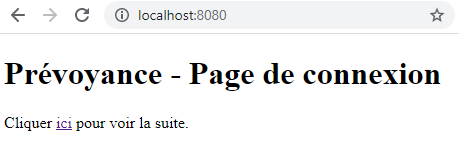

- Cliquer sur le lien

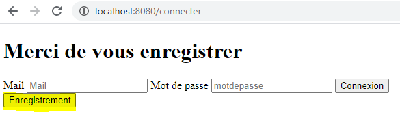

- Aller sur la page d'enregistrement

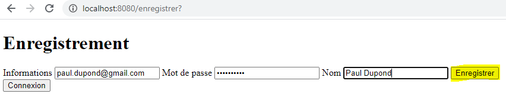

- Enregistrer un nouveau gestionnaire

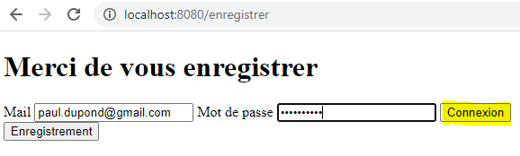

- Se connecter

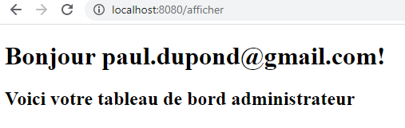

## Vérifier dans MongoDB les données insérées

- Dans la console, afficher les bases
- Se positionner sur la base `admin`
- Afficher les collections
- Afficher les données des gestionnaires prévoyance
- Afficher les rôles et vérifier que tous les gestionnaires prévoyance ont bien le rôle `ADMIN`